# Blazars/non-blazars samples definition

These note is to define the samples of blazars and non-blazar objects for future data analysis. Eventually, we will have a list of coordinates (RA,Dec), `ID` and *class* for each sample.

We are going to use the 5BzCat catalog of blazars (~3000 objects) and a list of AGNs from Paolo (~13k objects).

```python
import matplotlib
from matplotlib import pyplot as plt
%matplotlib inline

import seaborn as sns
print(sns.__version__)

import pandas as pd
print(pd.__version__)
```

```
0.9.0
0.23.4
```

```python
%ls
```

```
4carlosAll.csv              AGNSample_Label_RA_DEC.csv
4carlosAll.csv.BKP          AGN_AllColumns.csv
4carlosSeyf.txt             All_AGNs.ipynb
4carlosall.txt              BzCat.ipynb
5BZCAT.csv*                 PastedGraphic-1.pdf
5BZCAT.csv.BKP*             VOU_Blazars/
5bzcat_label_ra_dec.csv     tmp/
AGNSample_AllColumns.csv    work/
```

## AllAGNs: All AGNs sample

```python
agns = pd.read_csv('4carlosAll.csv', sep=',')
agns.sample(10)
```

|  | Name | RA(2000) | DEC(2000) | redsh | Vmag | Radio Fl | X Fl(mJ | Class |
| --- | --- | --- | --- | --- | --- | --- | --- | --- |
| 4488 | S5 0740+82 | 07 50 57.3 | 82 41 58 | 1.991 | 18.2 | 931.0 | 0.000 | QSO radio loud steep |
| 13 | WEE 3 | 00 03 26.9 | -01 59 54 | 2.220 | 19.7 | 0.0 | 0.000 | QSO radio quiet |
| 10399 | FBQS1626+30 | 16 26 59.2 | 30 15 35 | 1.580 | 17.5 | 0.0 | 0.000 | QSO radio loud |
| 9648 | Q 1451+4747 | 14 52 47.3 | 47 35 29 | 1.161 | 18.3 | 31.0 | 0.000 | QSO radio loud |
| 10569 | 1638.8+4012 | 16 40 29.5 | 40 07 14 | 1.183 | 19.4 | 0.0 | 0.000 | QSO radio quiet |
| 6364 | MARK 1298 | 11 29 16.7 | -04 24 08 | 0.060 | 14.6 | 1.0 | 0.034 | Seyfert type 1 |
| 9801 | 2E 1510+3902 | 15 12 30.7 | 38 50 51 | 0.228 | 18.5 | 0.0 | 0.011 | Galaxy unbarred |
| 423 | HBQS0035-35 | 00 38 17.2 | -35 04 05 | 1.519 | 18.3 | 0.0 | 0.000 | QSO radio quiet |
| 5898 | QNB1:20 | 10 43 06.6 | 01 08 49 | 2.503 | 20.6 | 0.0 | 0.000 | QSO radio quiet |
| 7105 | Q 1217+1236 | 12 20 14.1 | 12 20 20 | 1.047 | 18.2 | 0.0 | 0.000 | QSO radio quiet |

```python
def sex2deg(ra,dec):
    h,m,s = list(map(float,ra.split()))
    ra = s / 86400
    ra += m / 1440
    ra += h / 24
    ra *= 360

    d,m,s = dec.split()
    dec = float(s) / 3600
    dec += float(m) / 60
    if d[0] == '-':
        dec = float(d) - dec
    else:
        dec = float(d) + dec

    return ra,dec
```

```python
ra,dec = sex2deg('00 59 44.9','-00 21 30')

print(ra,dec)
```

```
14.937083333333332 -0.35833333333333334
```

```python
RA_COL = 'RA(2000)'
DEC_COL = 'DEC(2000)'

def apply_df(df):
    try:
        bla = list(sex2deg(df[RA_COL],df[DEC_COL]))
    except:
        bla = [None,None]
    return bla

agns[['RA','DEC']] = agns.apply(apply_df, axis=1, result_type='expand')
```

```python
agns.index.name = 'ID'
agns.reset_index(inplace=True)
agns
```

|  | ID | Name | RA(2000) | DEC(2000) | redsh | Vmag | Radio Fl | X Fl(mJ | Class | RA | DEC |
| --- | --- | --- | --- | --- | --- | --- | --- | --- | --- | --- | --- |
| 0 | 0 | WEE 1 | 00 02 37.4 | -02 21 12 | 1.740 | 18.5 | 0.0 | 0.000 | QSO radio quiet | 0.655833 | -2.353333 |
| 1 | 1 | Q 0000+0159 | 00 02 38.0 | 02 15 58 | 1.073 | 18.1 | 0.0 | 0.000 | QSO radio quiet | 0.658333 | 2.266111 |
| 2 | 2 | BG KPN 1 | 00 02 53.7 | 01 26 19 | 2.803 | 20.6 | 0.0 | 0.000 | QSO radio quiet | 0.723750 | 1.438611 |
| 3 | 3 | Q 0000+025A | 00 02 57.9 | 02 48 38 | 1.684 | 17.2 | 0.0 | 0.000 | QSO radio quiet | 0.741250 | 2.810556 |
| 4 | 4 | Q 0000+027A | 00 03 00.5 | 03 02 25 | 2.384 | 17.7 | 0.0 | 0.000 | QSO radio quiet | 0.752083 | 3.040278 |
| 5 | 5 | Q 0000-029 | 00 03 01.4 | -02 41 41 | 2.310 | 17.7 | 0.0 | 0.000 | QSO radio quiet | 0.755833 | -2.694722 |
| 6 | 6 | Q 0000-398 | 00 03 03.6 | -39 32 08 | 2.827 | 18.5 | 0.0 | 0.000 | QSO radio loud flat | 0.765000 | -39.535556 |
| 7 | 7 | MARK 334 | 00 03 09.6 | 21 57 36 | 0.022 | 14.6 | 11.0 | 0.240 | Seyfert type 1 | 0.790000 | 21.960000 |
| 8 | 8 | UM 16 | 00 03 10.1 | 04 44 55 | 0.058 | 16.1 | 0.0 | 0.000 | Seyfert type 2 | 0.792083 | 4.748611 |
| 9 | 9 | Q 0000+025B | 00 03 19.8 | 02 51 34 | 0.310 | 17.7 | 0.0 | 0.000 | QSO radio quiet | 0.832500 | 2.859444 |
| 10 | 10 | WEE 2 | 00 03 21.5 | -02 00 24 | 2.200 | 20.4 | 0.0 | 0.000 | QSO radio quiet | 0.839583 | -2.006667 |
| 11 | 11 | PKS 0000-17 | 00 03 22.1 | -17 27 14 | 1.465 | 18.7 | 894.0 | 0.000 | QSO radio loud steep | 0.842083 | -17.453889 |
| 12 | 12 | Q 0000-26 | 00 03 23.0 | -26 03 18 | 4.111 | 17.2 | 0.0 | 0.003 | QSO radio quiet | 0.845833 | -26.055000 |
| 13 | 13 | WEE 3 | 00 03 26.9 | -01 59 54 | 2.220 | 19.7 | 0.0 | 0.000 | QSO radio quiet | 0.862083 | -1.998333 |
| 14 | 14 | Q 0000-4244 | 00 03 27.3 | -42 27 22 | 1.700 | 20.1 | 0.0 | 0.000 | QSO radio quiet | 0.863750 | -42.456111 |
| 15 | 15 | Q 0000-4239 | 00 03 29.2 | -42 22 32 | 2.190 | 20.8 | 0.0 | 0.000 | QSO radio quiet | 0.871667 | -42.375556 |
| 16 | 16 | BG KPN 2 | 00 03 30.3 | 00 08 12 | 2.590 | 20.3 | 0.0 | 0.000 | QSO radio quiet | 0.876250 | 0.136667 |
| 17 | 17 | BG KPN 3 | 00 03 31.1 | 01 54 18 | 2.220 | 19.7 | 0.0 | 0.000 | QSO radio quiet | 0.879583 | 1.905000 |
| 18 | 18 | NGC 7808 | 00 03 32.1 | -10 44 40 | 0.029 | 14.8 | 0.0 | 0.000 | Seyfert type 1 | 0.883750 | -10.744444 |
| 19 | 19 | Q 0001+0214 | 00 03 36.1 | 02 30 49 | 0.232 | 20.7 | 0.0 | 0.000 | Galaxy unbarred | 0.900417 | 2.513611 |
| 20 | 20 | 0001+0842 | 00 03 42.6 | 08 59 40 | 3.241 | 19.0 | 0.0 | 0.000 | QSO radio quiet | 0.927500 | 8.994444 |
| 21 | 21 | TEX 0001-121 | 00 03 42.9 | -11 51 48 | 1.300 | 17.7 | 0.0 | 0.000 | QSO radio loud | 0.928750 | -11.863333 |
| 22 | 22 | Q 0001-007A | 00 03 49.9 | -00 26 53 | 2.190 | 17.7 | 0.0 | 0.000 | QSO radio quiet | 0.957917 | -0.448056 |
| 23 | 23 | Q 0001-0159 | 00 03 51.1 | -01 42 45 | 1.364 | 17.4 | 0.0 | 0.000 | QSO radio quiet | 0.962917 | -1.712500 |
| 24 | 24 | Q 0001-4227 | 00 03 50.8 | -42 11 08 | 2.240 | 18.9 | 0.0 | 0.000 | QSO radio quiet | 0.961667 | -42.185556 |
| 25 | 25 | BG CFH 1 | 00 03 55.9 | -00 55 27 | 2.490 | 21.8 | 0.0 | 0.000 | QSO radio quiet | 0.982917 | -0.924167 |
| 26 | 26 | Q 0001-4256 | 00 03 56.6 | -42 39 27 | 2.030 | 18.5 | 0.0 | 0.000 | QSO radio quiet | 0.985833 | -42.657500 |
| 27 | 27 | BG CFH 2 | 00 03 60.0 | -00 30 37 | 0.354 | 20.1 | 0.0 | 0.000 | Galaxy unbarred | 1.000000 | -0.510278 |
| 28 | 28 | BG CFH 3 | 00 04 01.2 | -00 39 01 | 2.340 | 20.7 | 0.0 | 0.000 | QSO radio quiet | 1.005000 | -0.650278 |
| 29 | 29 | Q 0001+022A | 00 04 01.6 | 02 31 50 | 2.260 | 18.2 | 0.0 | 0.000 | QSO radio quiet | 1.006667 | 2.530556 |
| ... | ... | ... | ... | ... | ... | ... | ... | ... | ... | ... | ... |
| 13346 | 13346 | PB 5679 | 00 00 58.1 | -00 46 47 | 1.920 | 17.7 | 0.0 | 0.000 | QSO radio quiet | 0.242083 | -0.779722 |
| 13347 | 13347 | KAZ 238 | 00 00 58.1 | 33 20 39 | 0.043 | 16.1 | 0.0 | 0.000 | Seyfert type 2 | 0.242083 | 33.344167 |
| 13348 | 13348 | WEE 188 | 00 01 01.8 | -02 15 42 | 0.060 | 21.0 | 0.0 | 0.000 | Galaxy unbarred | 0.257500 | -2.261667 |
| 13349 | 13349 | PKS 2358-161 | 00 01 05.4 | -15 51 08 | 2.044 | 18.3 | 305.0 | 0.000 | QSO radio loud steep | 0.272500 | -15.852222 |
| 13350 | 13350 | TEX 2358+189 | 00 01 08.6 | 19 14 34 | 3.100 | 20.2 | 197.0 | 0.000 | QSO radio loud flat | 0.285833 | 19.242778 |
| 13351 | 13351 | PB 5682 | 00 01 09.4 | 01 26 39 | 0.724 | 18.4 | 0.0 | 0.000 | QSO radio quiet | 0.289167 | 1.444167 |
| 13352 | 13352 | UM 194 | 00 01 16.6 | 00 02 07 | 0.780 | 18.2 | 0.0 | 0.000 | QSO radio quiet | 0.319167 | 0.035278 |
| 13353 | 13353 | Q 2358+025 | 00 01 19.2 | 02 49 18 | 2.750 | 17.7 | 0.0 | 0.000 | QSO radio quiet | 0.330000 | 2.821667 |
| 13354 | 13354 | Q 2358+0216 | 00 01 21.7 | 02 33 04 | 1.872 | 18.3 | 0.0 | 0.000 | QSO radio quiet | 0.340417 | 2.551111 |
| 13355 | 13355 | Q 2358+010 | 00 01 29.4 | 01 17 10 | 0.370 | 19.0 | 0.0 | 0.000 | Galaxy unbarred | 0.372500 | 1.286111 |
| 13356 | 13356 | 2359+0653 | 00 01 40.6 | 07 09 54 | 3.234 | 18.4 | 0.0 | 0.000 | QSO radio quiet | 0.419167 | 7.165000 |
| 13357 | 13357 | UM 195 | 00 01 46.2 | -01 59 34 | 0.867 | 18.3 | 0.0 | 0.000 | QSO radio quiet | 0.442500 | -1.992778 |
| 13358 | 13358 | BG KPN 9 | 00 01 46.8 | 00 39 59 | 2.897 | 19.6 | 0.0 | 0.000 | QSO radio quiet | 0.445000 | 0.666389 |
| 13359 | 13359 | BG KPN 10 | 00 01 47.1 | 00 14 27 | 2.120 | 20.5 | 0.0 | 0.000 | QSO radio quiet | 0.446250 | 0.240833 |
| 13360 | 13360 | Q 2359-004 | 00 01 49.5 | -00 10 39 | 2.190 | 18.2 | 0.0 | 0.000 | QSO radio quiet | 0.456250 | -0.177500 |
| 13361 | 13361 | BG KPN 11 | 00 01 49.7 | 01 11 43 | 2.140 | 21.0 | 0.0 | 0.000 | QSO radio quiet | 0.457083 | 1.195278 |
| 13362 | 13362 | UM 196 | 00 01 50.0 | -01 59 40 | 2.818 | 18.6 | 0.0 | 0.000 | QSO radio quiet | 0.458333 | -1.994444 |
| 13363 | 13363 | Q 2359-011 | 00 01 54.0 | -00 50 04 | 2.780 | 16.7 | 0.0 | 0.000 | QSO radio quiet | 0.475000 | -0.834444 |
| 13364 | 13364 | Q 2359+022 | 00 01 56.7 | 02 33 25 | 2.370 | 17.7 | 0.0 | 0.000 | QSO radio quiet | 0.486250 | 2.556944 |
| 13365 | 13365 | Q 2359-397 | 00 01 58.2 | -39 27 37 | 2.030 | 18.7 | 28.0 | 0.000 | QSO radio loud flat | 0.492500 | -39.460278 |
| 13366 | 13366 | PB 5692 | 00 02 01.5 | 03 10 19 | 1.320 | 17.2 | 0.0 | 0.000 | QSO radio quiet | 0.506250 | 3.171944 |
| 13367 | 13367 | Q 2359+011A | 00 02 06.4 | 01 25 25 | 0.810 | 18.7 | 0.0 | 0.000 | QSO radio quiet | 0.526667 | 1.423611 |
| 13368 | 13368 | BG KPN 12 | 00 02 12.0 | 00 32 51 | 2.670 | 19.7 | 0.0 | 0.000 | QSO radio quiet | 0.550000 | 0.547500 |
| 13369 | 13369 | Q 2359+0158 | 00 02 15.6 | 02 15 17 | 1.570 | 18.4 | 0.0 | 0.000 | QSO radio quiet | 0.565000 | 2.254722 |
| 13370 | 13370 | PB 5694 | 00 02 22.5 | -00 04 44 | 0.810 | 18.3 | 0.0 | 0.000 | QSO radio quiet | 0.593750 | -0.078889 |
| 13371 | 13371 | CFHT 00.0207 | 00 02 24.5 | -00 41 29 | 1.352 | 21.6 | 0.0 | 0.000 | Galaxy unbarred | 0.602083 | -0.691389 |
| 13372 | 13372 | MARK 543 | 00 02 26.3 | 03 21 09 | 0.026 | 14.7 | 0.0 | 0.564 | Seyfert type 1 | 0.609583 | 3.352500 |
| 13373 | 13373 | BG KPN 13 | 00 02 27.0 | 01 26 49 | 2.990 | 20.3 | 0.0 | 0.000 | QSO radio quiet | 0.612500 | 1.446944 |
| 13374 | 13374 | PB 5698 | 00 02 30.8 | 00 49 56 | 1.360 | 19.4 | 0.0 | 0.000 | QSO radio quiet | 0.628333 | 0.832222 |
| 13375 | 13375 | Q 2359-003B | 00 02 31.0 | -00 06 51 | 1.580 | 16.7 | 0.0 | 0.000 | QSO radio quiet | 0.629167 | -0.114167 |

13376 rows × 11 columns

```python
agns.groupby('Class').size().sort_values(ascending=False)
```

```
Class
QSO radio quiet         6842
QSO radio loud flat     1300
Galaxy unbarred         1164
Seyfert type 1           982
QSO radio loud steep     841
Seyfert type 2           467
BL Lac                   417
Radio Galaxy             299
Radio Galaxy radio l     288
QSO radio loud           246
QSO                      196
Starburst galaxy         144
unidentified              84
Liner                     51
Radio Galaxy radio q      44
Spiral galaxy mixed        3
AGN unclassified           3
Spiral galaxy              1
Non-active galaxy          1
Spiral galaxy barred       1
Elliptical galaxy          1
Cluster of galaxies        1
dtype: int64
```

### Define the columns of interest

```python
col = dict(ra='RA',
           dec='DEC',
           idn='ID',
           name='Name',
           redshift='redsh',
           flux_opt='Vmag',
           flux_radio='Radio Fl',
           flux_xray='X Fl(mJ',
           klass='Class'
          )
```

```python
# Remove objects without radio flux
#
agns = agns.loc[agns[col['flux_radio']] > 0]


# Keep only the columns of interest
#
agns = agns[list(col.values())]

# And let's order our catalog by their Radio flux
#
agns = agns.sort_values(col['flux_radio'], ascending=False).reset_index(drop=True)

# Create a "label" column for running and labeling it in VOU-Blazas
#
agns['label'] = agns[col['idn']].astype(str) +'_'+ agns[col['ra']].round(4).astype(str).str.replace('.','_') +'_'+ agns[col['dec']].round(4).astype(str).str.replace('.','_')

columns = agns.columns
columns = [columns[i-1] for i in range(len(columns))]

agns = agns[columns]
```

```python
agns
```

|  | label | RA | DEC | ID | Name | redsh | Vmag | Radio Fl | X Fl(mJ | Class |
| --- | --- | --- | --- | --- | --- | --- | --- | --- | --- | --- |
| 0 | 11139_299_8679_40_7339 | 299.867917 | 40.733889 | 11139 | 3C 405.0 | 0.056 | 14.5 | 213100.0 | 4.013 | QSO radio loud steep |
| 1 | 7330_187_7054_12_3908 | 187.705417 | 12.390833 | 7330 | 1Jy1228+126 | 0.004 | 12.9 | 74890.0 | 3.893 | Radio Galaxy radio l |
| 2 | 3556_50_6725_-37_2092 | 50.672500 | -37.209167 | 3556 | 1Jy0320-374 | 0.006 | 9.1 | 71133.0 | 0.111 | Radio Galaxy radio l |
| 3 | 3555_50_6717_-37_2075 | 50.671667 | -37.207500 | 3555 | For A | 0.006 | 8.8 | 71133.0 | 0.111 | Radio Galaxy radio l |
| 4 | 3535_49_9504_41_5117 | 49.950417 | 41.511667 | 3535 | 3C84 | 0.017 | 11.9 | 47261.0 | 17.514 | Radio Galaxy radio l |
| 5 | 3536_49_9504_41_5117 | 49.950417 | 41.511667 | 3536 | S40316+413 | 0.018 | 11.9 | 47200.0 | 17.514 | Radio Galaxy radio l |
| 6 | 3537_49_9504_41_5117 | 49.950417 | 41.511667 | 3537 | 1Jy0316+413 | 0.017 | 11.9 | 46310.0 | 17.514 | Radio Galaxy radio l |
| 7 | 7297_187_2779_2_0522 | 187.277917 | 2.052222 | 7297 | 3C 273.0 | 0.158 | 12.8 | 40117.0 | 17.223 | QSO radio loud flat |
| 8 | 7296_187_2775_2_0522 | 187.277500 | 2.052222 | 7296 | 3C273 | 0.158 | 12.8 | 40117.0 | 17.223 | QSO radio loud flat |
| 9 | 7295_187_2775_2_0522 | 187.277500 | 2.052222 | 7295 | 1Jy1226+023 | 0.158 | 12.8 | 40117.0 | 17.223 | QSO radio loud flat |
| 10 | 12799_343_4904_16_1481 | 343.490417 | 16.148056 | 12799 | 3C454.3 | 0.860 | 16.1 | 23261.0 | 1.033 | QSO radio loud flat |
| 11 | 12798_343_4904_16_1481 | 343.490417 | 16.148056 | 12798 | 1Jy2251+158 | 0.860 | 16.1 | 23261.0 | 1.033 | QSO radio loud flat |
| 12 | 12797_343_4904_16_1481 | 343.490417 | 16.148056 | 12797 | 3C 454.3 | 0.860 | 16.1 | 23261.0 | 1.033 | QSO radio loud flat |
| 13 | 10767_260_1171_-0_9794 | 260.117083 | -0.979444 | 10767 | 1Jy1717-009 | 0.030 | 15.4 | 22150.0 | 0.000 | Radio Galaxy radio l |
| 14 | 10766_260_1171_-0_9797 | 260.117083 | -0.979722 | 10766 | 3C353 | 0.031 | 15.8 | 20143.0 | 0.000 | Radio Galaxy radio l |
| 15 | 3971_69_2679_29_6703 | 69.267917 | 29.670278 | 3971 | 3C123 | 0.218 | 19.9 | 16229.0 | 0.000 | Radio Galaxy radio l |
| 16 | 7869_194_0462_-5_7892 | 194.046250 | -5.789167 | 7869 | 3C279 | 0.538 | 17.8 | 16110.0 | 1.171 | QSO radio loud flat |
| 17 | 7868_194_0462_-5_7892 | 194.046250 | -5.789167 | 7868 | 3C 279 | 0.538 | 17.8 | 16110.0 | 1.171 | QSO radio loud flat |
| 18 | 7870_194_0462_-5_7892 | 194.046250 | -5.789167 | 7870 | 1Jy1253-055 | 0.538 | 17.8 | 16110.0 | 1.171 | QSO radio loud flat |
| 19 | 3970_69_2679_29_6703 | 69.267917 | 29.670278 | 3970 | 1Jy0433+295 | 0.218 | 21.7 | 15940.0 | 0.000 | Radio Galaxy radio l |
| 20 | 4180_79_9542_-45_7794 | 79.954167 | -45.779444 | 4180 | Pic A | 0.035 | 16.0 | 14999.0 | 2.066 | Radio Galaxy |
| 21 | 4179_79_9542_-45_7794 | 79.954167 | -45.779444 | 4179 | 1Jy0518-458 | 0.035 | 15.8 | 14999.0 | 2.066 | Radio Galaxy |
| 22 | 4178_79_9542_-45_7794 | 79.954167 | -45.779444 | 4178 | PKS 0518-45 | 0.035 | 15.8 | 14999.0 | 2.066 | Radio Galaxy |
| 23 | 5054_139_5262_-12_0964 | 139.526250 | -12.096389 | 5054 | 1Jy0915-118 | 0.055 | 14.8 | 13990.0 | 2.235 | Radio Galaxy radio l |
| 24 | 5053_139_5238_-12_0953 | 139.523750 | -12.095278 | 5053 | 3C 218 | 0.054 | 14.7 | 13497.0 | 2.235 | Radio Galaxy radio l |
| 25 | 5052_139_5233_-12_0953 | 139.523333 | -12.095278 | 5052 | Hyd A | 0.054 | 14.7 | 13497.0 | 2.235 | Radio Galaxy radio l |
| 26 | 8453_201_3671_-43_0167 | 201.367083 | -43.016667 | 8453 | CENTAURUS-A | 0.002 | 7.0 | 13367.0 | 5.746 | Radio Galaxy radio l |
| 27 | 11990_329_2738_-69_6897 | 329.273750 | -69.689722 | 11990 | 2152-69 | 0.027 | 14.0 | 12442.0 | 1.273 | QSO radio loud steep |
| 28 | 11991_329_2742_-69_6897 | 329.274167 | -69.689722 | 11991 | PKS 2153-69 | 0.027 | 14.0 | 12442.0 | 1.273 | QSO radio loud steep |
| 29 | 10665_252_7842_4_9906 | 252.784167 | 4.990556 | 10665 | Her A | 0.154 | 16.9 | 12413.0 | 0.275 | Radio Galaxy |
| ... | ... | ... | ... | ... | ... | ... | ... | ... | ... | ... |
| 3797 | 4408_109_2108_36_91 | 109.210833 | 36.910000 | 4408 | MS 07134+3700 | 0.122 | 16.8 | 1.0 | 0.124 | Seyfert type 1 |
| 3798 | 4060_73_1833_-3_2169 | 73.183333 | -3.216944 | 4060 | IRAS 04502-0317 | 0.016 | 15.0 | 1.0 | 0.011 | Seyfert type 2 |
| 3799 | 13001_351_8808_12_385 | 351.880833 | 12.385000 | 13001 | NGC 7672 | 0.013 | 14.2 | 1.0 | 0.000 | Seyfert type 2 |
| 3800 | 4056_72_9054_-18_3122 | 72.905417 | -18.312222 | 4056 | MS 04494-1823 | 0.338 | 17.6 | 1.0 | 0.182 | Seyfert type 2 |
| 3801 | 4038_72_155_-6_32 | 72.155000 | -6.320000 | 4038 | NGC 1667 | 0.015 | 12.9 | 1.0 | 0.000 | Seyfert type 2 |
| 3802 | 3998_70_4075_2_0633 | 70.407500 | 2.063333 | 3998 | MS 04390+0158 | 0.196 | 18.7 | 1.0 | 0.169 | Seyfert type 1 |
| 3803 | 3697_55_5188_-21_2442 | 55.518750 | -21.244167 | 3697 | ESO 548-G81 | 0.015 | 13.7 | 1.0 | 1.381 | Seyfert type 1 |
| 3804 | 3610_53_4154_-5_0894 | 53.415417 | -5.089444 | 3610 | NGC 1358 | 0.013 | 13.1 | 1.0 | 0.000 | Seyfert type 2 |
| 3805 | 5424_149_8733_-22_8261 | 149.873333 | -22.826111 | 5424 | NGC 3081 | 0.007 | 13.6 | 1.0 | 0.092 | Seyfert type 2 |
| 3806 | 5571_153_7288_0_5603 | 153.728750 | 0.560278 | 5571 | PG 1012+008 | 0.185 | 15.6 | 1.0 | 0.685 | Seyfert type 1 |
| 3807 | 7606_190_045_10_7364 | 190.045000 | 10.736389 | 7606 | Q 1237+1100 | 0.881 | 18.2 | 1.0 | 0.000 | QSO radio quiet |
| 3808 | 6070_164_1092_-4_1778 | 164.109167 | -4.177778 | 6070 | Q 1053-038 | 0.452 | 17.9 | 1.0 | 0.064 | QSO radio quiet |
| 3809 | 7560_189_6483_17_7619 | 189.648333 | 17.761944 | 7560 | Q 1236+1802 | 0.517 | 18.4 | 1.0 | 0.000 | QSO radio loud |
| 3810 | 7368_188_015_20_1583 | 188.015000 | 20.158333 | 7368 | TON 1542 | 0.064 | 15.3 | 1.0 | 1.237 | Seyfert type 1 |
| 3811 | 7366_187_9092_70_7339 | 187.909167 | 70.733889 | 7366 | 1ES 1229+710 | 0.208 | 0.0 | 1.0 | 0.705 | Seyfert type 1 |
| 3812 | 7350_187_8912_8_2997 | 187.891250 | 8.299722 | 7350 | Q 1229+0834 | 0.761 | 18.3 | 1.0 | 0.000 | QSO radio loud |
| 3813 | 7228_186_4538_33_5469 | 186.453750 | 33.546944 | 7228 | NGC 4395 | 0.001 | 10.1 | 1.0 | 0.006 | Seyfert type 1 |
| 3814 | 7163_185_8242_9_3856 | 185.824167 | 9.385556 | 7163 | Q 1220+0939 | 0.681 | 17.3 | 1.0 | 0.053 | QSO radio quiet |
| 3815 | 7141_185_4338_75_3106 | 185.433750 | 75.310556 | 7141 | MARK 205 | 0.070 | 15.2 | 1.0 | 1.669 | Seyfert type 1 |
| 3816 | 6970_183_6675_14_4831 | 183.667500 | 14.483056 | 6970 | Q 1212+1445 | 1.627 | 17.6 | 1.0 | 0.000 | QSO radio quiet |
| 3817 | 6963_183_5738_14_0536 | 183.573750 | 14.053611 | 6963 | PG 1211+143 | 0.085 | 14.2 | 1.0 | 1.006 | Seyfert type 1 |
| 3818 | 6812_181_1754_27_9033 | 181.175417 | 27.903333 | 6812 | GQ COM | 0.165 | 15.6 | 1.0 | 0.341 | Seyfert type 1 |
| 3819 | 6773_180_3104_-3_6778 | 180.310417 | -3.677778 | 6773 | MARK 1310 | 0.019 | 15.5 | 1.0 | 0.362 | Seyfert type 1 |
| 3820 | 6696_178_5517_0_1367 | 178.551667 | 0.136667 | 6696 | MARK 1308 | 0.004 | 14.2 | 1.0 | 0.000 | Starburst galaxy |
| 3821 | 12553_338_5375_0_0006 | 338.537500 | 0.000556 | 12553 | Q 2231-0015 | 3.015 | 17.2 | 1.0 | 0.000 | QSO radio quiet |
| 3822 | 6649_177_8354_54_6258 | 177.835417 | 54.625833 | 6649 | PG 1148+549 | 0.978 | 15.8 | 1.0 | 0.047 | QSO radio quiet |
| 3823 | 6444_174_1221_21_5961 | 174.122083 | 21.596111 | 6444 | MARK 739E | 0.030 | 14.1 | 1.0 | 0.713 | Seyfert type 1 |
| 3824 | 6306_170_4462_11_7386 | 170.446250 | 11.738611 | 6306 | MARK 734 | 0.049 | 14.9 | 1.0 | 0.578 | Seyfert type 1 |
| 3825 | 6225_168_2454_21_9094 | 168.245417 | 21.909444 | 6225 | MS 11103+2210 | 0.030 | 16.6 | 1.0 | 0.074 | Seyfert type 1 |
| 3826 | 6364_172_3196_-4_4022 | 172.319583 | -4.402222 | 6364 | MARK 1298 | 0.060 | 14.6 | 1.0 | 0.034 | Seyfert type 1 |

3827 rows × 10 columns

```python
fileout = 'AGNSample_Label_RA_DEC.csv'
agns[['label', col['ra'], col['dec']]].to_csv(fileout, index=False, sep=" ", float_format='%.5f')

fileout = 'AGNSample_AllColumns.csv'
agns.to_csv(fileout, index=False, sep=" ", float_format='%.5f')
```

```python
# for gn,grp in agns.groupby('Class'):
#     obj_class_name = gn.replace(' ','_')
#     print(obj_class_name, len(grp))
#     fileout = 'AGNSample_{}.csv'.format(obj_class_name)
#     grp[['label', col['ra'], col['dec']]].to_csv(fileout, index=False, sep=" ", float_format='%.5f')
```

```python
agns.groupby('Class').size().sort_values(ascending=False)
```

```
Class
QSO radio loud flat     1298
QSO radio loud steep     841
BL Lac                   405
Radio Galaxy             299
Radio Galaxy radio l     284
Seyfert type 1           162
QSO radio loud           135
Seyfert type 2           120
unidentified              56
Starburst galaxy          53
QSO radio quiet           47
Radio Galaxy radio q      44
Galaxy unbarred           27
QSO                       26
Liner                     24
Spiral galaxy mixed        2
Spiral galaxy              1
Spiral galaxy barred       1
Elliptical galaxy          1
Cluster of galaxies        1
dtype: int64
```

```python
agns = agns.dropna()
```

## Spectra retrieval

At this point, the SED of each object (providing one) is built from `VOU-Blazars` (`VOUB` hereafter). Results of `VOUB` are placed in `./work/AGN_all_radio_non_null/Results`, in particular the SEDs go inside `SEDtool/` in that dir.

```python
%ls work/AGN_all_radio_non_null/Results/
```

```
10000_232_8554_35_5608/  2003_20_4179_-63_1506/   5300_146_9383_7_4222/
10001_232_9304_24_0717/  2004_20_6617_25_0422/    5301_147_3008_66_2497/
10002_232_9304_24_0717/  2005_20_6158_-4_3575/    5302_147_3008_66_2497/
10003_232_9308_24_0717/  2006_20_6692_23_1708/    5306_146_9175_-30_9483/
10010_233_3129_13_5403/  200_4_1363_79_2806/      5309_147_5683_72_2833/
10013_233_4183_35_7392/  2014_20_7862_34_3469/    530_10_655_3_2392/
10014_232_8892_72_1111/  201_4_0454_-0_2536/      5310_147_2304_40_6622/
10015_232_8904_72_1114/  202_4_2837_81_5853/      5311_147_2304_40_6622/
10017_233_6346_15_195/   203_4_285_81_5856/       5312_147_2304_40_6622/
10018_233_7183_1_5172/   2044_21_1117_33_7994/    5314_147_0396_-32_3961/
10019_233_7187_1_5181/   2045_20_9767_-35_0656/   5318_147_2742_-19_9528/
10022_233_7388_23_5033/  2055_21_1288_11_095/     5325_147_5446_14_3325/
10024_233_7533_53_3431/  2056_21_1875_32_1656/    5339_148_1133_50_8142/
10025_233_7533_53_3436/  2062_21_1992_32_1239/    5340_148_0329_29_2369/
10026_233_7383_58_6567/  2064_21_1471_3_7919/     5342_148_1104_36_1014/
10028_234_195_1_6328/    2067_21_1446_-4_0172/    5343_148_1329_35_2147/
10030_233_9671_49_9608/  206_4_2583_32_1564/      5346_148_0796_-1_6122/
10032_234_0717_46_4589/  2070_21_1854_9_3136/     5347_148_6975_74_5989/
10033_233_9679_57_9025/  2071_21_4946_72_7625/    5348_148_1892_0_0047/
10039_234_7246_17_025/   2080_21_3808_32_1364/    5353_148_5408_49_2494/
10041_234_8646_24_9481/  2082_21_3217_-0_3078/    5354_148_5412_49_2497/
10045_234_895_47_5919/   2091_21_3704_-0_0989/    5357_148_8883_69_0653/
10046_235_2058_14_7958/  2092_21_3704_-0_0994/    5360_148_9612_69_6786/
10047_235_2062_14_7961/  2099_21_7692_73_3869/    5361_148_9612_69_6786/
10050_235_2442_47_6411/  2106_21_5021_-1_345/     5362_148_9612_69_6786/
10052_235_5508_18_5881/  2107_21_5025_-1_345/     5366_148_7367_17_7253/
10053_235_5812_17_9356/  2120_21_5621_-22_3758/   5367_148_7371_9_4986/
10054_235_3558_53_8039/  2122_21_6846_33_2197/    5368_148_8688_43_9589/
10057_235_7342_10_9103/  2123_21_685_33_2192/     5369_148_9158_45_5381/
10059_237_7454_-82_9683/ 2125_21_6783_25_9836/    5371_148_9083_33_5844/
10063_235_7542_35_4208/  2136_22_9879_84_7703/    5372_148_9504_35_5564/
10064_236_0779_4_9728/   2137_21_81_-41_2119/     5386_149_2179_41_2558/
10068_236_2479_4_1297/   2142_21_9333_-34_965/    5390_149_2075_25_2542/
10072_236_1883_37_2189/  2161_22_4987_23_6389/    5391_149_2079_25_2544/
10075_236_2854_47_8653/  2162_22_4996_23_6389/    5392_149_4088_55_3828/
10078_236_3758_48_7694/  2181_22_8317_-40_7647/   5393_149_4088_55_3825/
10079_236_5738_17_2336/  2196_23_1808_-16_9131/   5394_149_4088_55_3825/
10080_235_0654_81_9183/  2197_23_1812_-16_9136/   5395_149_4092_55_3828/
10087_236_9317_20_8711/  2202_23_38_35_6681/      5399_149_6967_65_5653/
10090_236_8375_49_6181/  2203_23_3525_24_4611/    539_10_7867_52_0589/
```

[output cut: 1220 more lines]

```
1926_19_8954_32_1806/    5249_145_7121_27_6328/   9961_231_1738_15_3558/
1927_19_8958_32_1808/    5256_145_9038_-8_3253/   9967_231_2621_11_1289/
1941_19_9438_-17_7967/   5262_145_9587_-20_3256/  9968_231_0242_54_4692/
1955_20_1129_-15_3378/   5263_146_2183_52_0425/   996_13_435_29_4189/
1956_20_1129_-15_3381/   5264_146_0688_9_7711/    9973_231_7471_-13_85/
1957_20_1133_-15_3383/   5267_146_1762_25_9122/   9975_231_5254_41_6708/
1961_20_1312_-27_0233/   5277_146_4579_12_0919/   9976_231_6929_9_9861/
1962_20_1321_-27_0236/   5279_146_425_-14_3264/   9981_231_5725_48_0661/
1971_20_2558_3_7369/     528_10_6412_3_2564/      9985_231_8275_31_2567/
1979_20_4233_11_8306/    5290_146_7204_13_3275/   9986_231_9904_22_5511/
1980_20_4233_11_8303/    5291_147_2529_73_2297/   9991_232_3233_47_6439/
1988_20_4867_4_3733/     5296_146_9412_11_2317/   9995_232_665_33_9283/
1989_20_4871_4_3736/     5298_146_9375_7_42/      9996_232_8254_7_4578/
1992_20_4992_-1_04/      5299_146_9379_7_4222/    99_1_8629_2_6867/
199_4_1288_79_2806/      529_10_6879_41_2728/     SEDtool/
```

```python
%ls work/AGN_all_radio_non_null/Results/SEDtool/
```

```
0_08471_m32_34972_sedtool.txt    228_43700_m10_20008_sedtool.txt
0_27204_m15_85194_sedtool.txt    228_67065_36_84985_sedtool.txt
0_28596_19_24286_sedtool.txt     229_16752_0_25059_sedtool.txt
0_79004_21_96022_sedtool.txt     229_18322_7_01895_sedtool.txt
100_51762_67_97656_sedtool.txt   229_23660_19_53692_sedtool.txt
101_10529_m34_99497_sedtool.txt  229_42438_m24_37222_sedtool.txt
101_63371_44_85469_sedtool.txt   229_44812_65_42322_sedtool.txt
102_05879_m30_73867_sedtool.txt  229_52556_42_74584_sedtool.txt
102_11871_m17_73486_sedtool.txt  22_49912_23_63872_sedtool.txt
102_53596_60_84575_sedtool.txt   22_83175_m40_76517_sedtool.txt
102_63008_60_02906_sedtool.txt   230_02285_20_26826_sedtool.txt
102_69346_25_04992_sedtool.txt   230_15442_16_02406_sedtool.txt
103_05200_74_42694_sedtool.txt   230_18167_47_54703_sedtool.txt
103_49279_37_09461_sedtool.txt   230_19775_72_41800_sedtool.txt
103_81352_54_14921_sedtool.txt   230_31904_2_64903_sedtool.txt
104_90890_54_19654_sedtool.txt   230_61982_m6_74495_sedtool.txt
105_72471_68_68781_sedtool.txt   230_65712_m27_50292_sedtool.txt
106_68225_42_49878_sedtool.txt   230_72867_34_23586_sedtool.txt
106_88355_38_36999_sedtool.txt   231_02350_54_47178_sedtool.txt
107_10188_34_92839_sedtool.txt   231_17323_15_35904_sedtool.txt
107_32392_74_82367_sedtool.txt   231_26216_11_12899_sedtool.txt
107_62568_59_13895_sedtool.txt   231_52567_41_67066_sedtool.txt
107_69210_47_53646_sedtool.txt   231_58488_48_05253_sedtool.txt
108_25333_11_76672_sedtool.txt   231_69303_9_98618_sedtool.txt
108_27807_36_93884_sedtool.txt   231_82804_31_25678_sedtool.txt
108_40904_43_82141_sedtool.txt   231_99088_22_55025_sedtool.txt
108_56290_45_69881_sedtool.txt   232_82462_7_45778_sedtool.txt
108_60339_35_57769_sedtool.txt   232_85346_35_56078_sedtool.txt
109_13038_m29_32431_sedtool.txt  232_88975_72_11150_sedtool.txt
109_16575_53_38752_sedtool.txt   232_92796_24_07422_sedtool.txt
109_21094_36_91012_sedtool.txt   233_31167_13_54040_sedtool.txt
109_46603_45_63429_sedtool.txt   233_41573_35_74597_sedtool.txt
109_50260_44_09086_sedtool.txt   233_63497_15_19378_sedtool.txt
109_51275_m26_13900_sedtool.txt  233_71853_1_51786_sedtool.txt
109_83089_33_11935_sedtool.txt   233_73853_58_65654_sedtool.txt
10_05625_40_83483_sedtool.txt    233_73860_23_50315_sedtool.txt
10_20979_10_05647_sedtool.txt    233_75328_53_34369_sedtool.txt
10_22921_33_16869_sedtool.txt    233_96685_49_96092_sedtool.txt
10_23847_m1_76804_sedtool.txt    233_96842_57_90265_sedtool.txt
10_35820_m1_72345_sedtool.txt    234_19464_1_63327_sedtool.txt
```

[output cut: 1031 more lines]

```
226_23800_26_01621_sedtool.txt   97_34908_m19_98878_sedtool.txt
226_27695_3_44190_sedtool.txt    97_79996_m41_90747_sedtool.txt
226_53981_37_51415_sedtool.txt   98_41183_17_99261_sedtool.txt
226_60300_83_32444_sedtool.txt   98_93771_m75_27092_sedtool.txt
226_71371_42_65580_sedtool.txt   99_84121_73_41619_sedtool.txt
226_77000_m16_87506_sedtool.txt  9_02729_18_63306_sedtool.txt
227_09887_33_78351_sedtool.txt   9_21800_m33_55350_sedtool.txt
227_44978_55_93813_sedtool.txt   9_26517_m1_14806_sedtool.txt
227_51235_57_04545_sedtool.txt   9_40300_39_63678_sedtool.txt
227_60025_70_75908_sedtool.txt   9_44225_36_98642_sedtool.txt
227_72330_m5_71858_sedtool.txt   9_49296_24_11989_sedtool.txt
227_96004_m32_71533_sedtool.txt  9_56142_m24_98389_sedtool.txt
227_99925_m21_31669_sedtool.txt  9_58360_m2_12588_sedtool.txt
228_06390_2_05797_sedtool.txt    9_60346_41_61839_sedtool.txt
228_21058_m9_10025_sedtool.txt   9_61204_m38_99617_sedtool.txt
```

## Recover results

To read the resulting SEDs, for each object, we may have to do some small processing on the RA/Dec values of each object to properly relate to the data/SED files. The reason is the name convention used used in the output files:

- directories in `Results/` are named after the given/input RA and Dec values; on the other hand,
- directories in `Results/SEDtool/` are named after the object's (assumed) Radio source position.

```python
ra_s1 = agns[col['ra']].astype(str)
ra_s1 = [s.split('.') for s in ra_s1]
ra_s1 = ['_'.join([l[0],l[1][:3]]) for l in ra_s1]

dec_s1 = agns[col['dec']].astype(str)
dec_s1 = [s.split('.') for s in dec_s1]
dec_s1 = ['_'.join([l[0],l[1][:3]]).replace('-','m') for l in dec_s1]

ids = agns['label']
```

```python
from os import path
from glob import glob
seds = [path.basename(p) for p in glob('work/AGN_all_radio_non_null/Results/SEDtool/*_sedtool.txt')]
seds_filename = seds[:]

seds = [s.replace('_sedtool.txt','') for s in seds]

seds = [s.split('_') for s in seds]

ra_s2 = ['_'.join([l[0],l[1][:3]]) for l in seds]

dec_s2 = ['_'.join([l[2],l[3][:3]]) for l in seds]
```

```python
df1 = pd.DataFrame(data={'ra_1':ra_s1, 'dec_1':dec_s1, 'ids':ids})

df2 = pd.DataFrame(data={'ra_2':ra_s2, 'dec_2':dec_s2, 'filenames':seds_filename})
```

```python
df1.head()
```

|  | ra_1 | dec_1 | ids |
| --- | --- | --- | --- |
| 0 | 299_867 | 40_733 | 11139_299_8679_40_7339 |
| 1 | 187_705 | 12_390 | 7330_187_7054_12_3908 |
| 2 | 50_672 | m37_209 | 3556_50_6725_-37_2092 |
| 3 | 50_671 | m37_207 | 3555_50_6717_-37_2075 |
| 4 | 49_950 | 41_511 | 3535_49_9504_41_5117 |

```python
df2.head()
```

|  | ra_2 | dec_2 | filenames |
| --- | --- | --- | --- |
| 0 | 0_084 | m32_349 | 0_08471_m32_34972_sedtool.txt |
| 1 | 0_272 | m15_851 | 0_27204_m15_85194_sedtool.txt |
| 2 | 0_285 | 19_242 | 0_28596_19_24286_sedtool.txt |
| 3 | 0_790 | 21_960 | 0_79004_21_96022_sedtool.txt |
| 4 | 100_517 | 67_976 | 100_51762_67_97656_sedtool.txt |

```python
df1['radec1'] = df1.apply(lambda x:'_'.join([x['ra_1'],x['dec_1']]), axis=1)
# df1.sort_values(['ra_1','dec_1'], inplace=True)
```

```python
df2['radec2'] = df2.apply(lambda x:'_'.join([x['ra_2'],x['dec_2']]), axis=1)
# df2.sort_values(['ra_2','dec_2'], inplace=True)
```

```python
df3 = df1.merge(df2, left_on='radec1', right_on='radec2', how='inner')
df3
```

|  | ra_1 | dec_1 | ids | radec1 | ra_2 | dec_2 | filenames | radec2 |
| --- | --- | --- | --- | --- | --- | --- | --- | --- |
| 0 | 49_950 | 41_511 | 3535_49_9504_41_5117 | 49_950_41_511 | 49_950 | 41_511 | 49_95067_41_51169_sedtool.txt | 49_950_41_511 |
| 1 | 49_950 | 41_511 | 3536_49_9504_41_5117 | 49_950_41_511 | 49_950 | 41_511 | 49_95067_41_51169_sedtool.txt | 49_950_41_511 |
| 2 | 49_950 | 41_511 | 3537_49_9504_41_5117 | 49_950_41_511 | 49_950 | 41_511 | 49_95067_41_51169_sedtool.txt | 49_950_41_511 |
| 3 | 343_490 | 16_148 | 12799_343_4904_16_1481 | 343_490_16_148 | 343_490 | 16_148 | 343_49042_16_14817_sedtool.txt | 343_490_16_148 |
| 4 | 343_490 | 16_148 | 12798_343_4904_16_1481 | 343_490_16_148 | 343_490 | 16_148 | 343_49042_16_14817_sedtool.txt | 343_490_16_148 |
| 5 | 343_490 | 16_148 | 12797_343_4904_16_1481 | 343_490_16_148 | 343_490 | 16_148 | 343_49042_16_14817_sedtool.txt | 343_490_16_148 |
| 6 | 324_160 | 0_698 | 11775_324_1604_0_6983 | 324_160_0_698 | 324_160 | 0_698 | 324_16074_0_69843_sedtool.txt | 324_160_0_698 |
| 7 | 324_160 | 0_698 | 11776_324_1604_0_6983 | 324_160_0_698 | 324_160 | 0_698 | 324_16074_0_69843_sedtool.txt | 324_160_0_698 |
| 8 | 80_741 | m36_458 | 4187_80_7413_-36_4583 | 80_741_m36_458 | 80_741 | m36_458 | 80_74179_m36_45833_sedtool.txt | 80_741_m36_458 |
| 9 | 80_741 | m36_458 | 4189_80_7413_-36_4583 | 80_741_m36_458 | 80_741 | m36_458 | 80_74179_m36_45833_sedtool.txt | 80_741_m36_458 |
| 10 | 80_741 | m36_458 | 4188_80_7413_-36_4583 | 80_741_m36_458 | 80_741 | m36_458 | 80_74179_m36_45833_sedtool.txt | 80_741_m36_458 |
| 11 | 141_762 | 39_039 | 5121_141_7625_39_0392 | 141_762_39_039 | 141_762 | 39_039 | 141_76260_39_03909_sedtool.txt | 141_762_39_039 |
| 12 | 172_529 | m14_824 | 6370_172_5292_-14_8242 | 172_529_m14_824 | 172_529 | m14_824 | 172_52938_m14_82422_sedtool.txt | 172_529_m14_824 |
| 13 | 172_529 | m14_824 | 6371_172_5292_-14_8242 | 172_529_m14_824 | 172_529 | m14_824 | 172_52938_m14_82422_sedtool.txt | 172_529_m14_824 |
| 14 | 70_071 | m43_552 | 3992_70_0712_-43_5522 | 70_071_m43_552 | 70_071 | m43_552 | 70_07112_m43_55250_sedtool.txt | 70_071_m43_552 |
| 15 | 70_071 | m43_552 | 3994_70_0717_-43_5525 | 70_071_m43_552 | 70_071 | m43_552 | 70_07112_m43_55250_sedtool.txt | 70_071_m43_552 |
| 16 | 212_835 | 52_202 | 9229_212_8354_52_2022 | 212_835_52_202 | 212_835 | 52_202 | 212_83580_52_20264_sedtool.txt | 212_835_52_202 |
| 17 | 212_835 | 52_202 | 9227_212_8354_52_2025 | 212_835_52_202 | 212_835 | 52_202 | 212_83580_52_20264_sedtool.txt | 212_835_52_202 |
| 18 | 212_835 | 52_202 | 9228_212_8354_52_2022 | 212_835_52_202 | 212_835 | 52_202 | 212_83580_52_20264_sedtool.txt | 212_835_52_202 |
| 19 | 294_854 | m63_712 | 11096_294_8542_-63_7128 | 294_854_m63_712 | 294_854 | m63_712 | 294_85454_m63_71267_sedtool.txt | 294_854_m63_712 |
| 20 | 277_382 | 48_746 | 10984_277_3821_48_7461 | 277_382_48_746 | 277_382 | 48_746 | 277_38250_48_74631_sedtool.txt | 277_382_48_746 |
| 21 | 277_382 | 48_746 | 10985_277_3821_48_7461 | 277_382_48_746 | 277_382 | 48_746 | 277_38250_48_74631_sedtool.txt | 277_382_48_746 |
| 22 | 277_382 | 48_746 | 10986_277_3821_48_7461 | 277_382_48_746 | 277_382 | 48_746 | 277_38250_48_74631_sedtool.txt | 277_382_48_746 |
| 23 | 277_382 | 48_746 | 10987_277_3825_48_7461 | 277_382_48_746 | 277_382 | 48_746 | 277_38250_48_74631_sedtool.txt | 277_382_48_746 |
| 24 | 88_878 | 39_813 | 4260_88_8783_39_8136 | 88_878_39_813 | 88_878 | 39_813 | 88_87833_39_81350_sedtool.txt | 88_878_39_813 |
| 25 | 24_421 | 33_159 | 2290_24_4217_33_1597 | 24_421_33_159 | 24_421 | 33_159 | 24_42196_33_15989_sedtool.txt | 24_421_33_159 |
| 26 | 24_421 | 33_159 | 2291_24_4217_33_1597 | 24_421_33_159 | 24_421 | 33_159 | 24_42196_33_15989_sedtool.txt | 24_421_33_159 |
| 27 | 327_022 | 6_960 | 11952_327_0229_6_9608 | 327_022_6_960 | 327_022 | 6_960 | 327_02276_6_96073_sedtool.txt | 327_022_6_960 |
| 28 | 327_022 | 6_960 | 11951_327_0225_6_9606 | 327_022_6_960 | 327_022 | 6_960 | 327_02276_6_96073_sedtool.txt | 327_022_6_960 |
| 29 | 327_022 | 6_960 | 11950_327_0225_6_9606 | 327_022_6_960 | 327_022 | 6_960 | 327_02276_6_96073_sedtool.txt | 327_022_6_960 |
| ... | ... | ... | ... | ... | ... | ... | ... | ... |
| 1085 | 169_786 | 21_321 | 6285_169_7867_21_3217 | 169_786_21_321 | 169_786 | 21_321 | 169_78622_21_32159_sedtool.txt | 169_786_21_321 |
| 1086 | 13_395 | 12_693 | 994_13_3954_12_6933 | 13_395_12_693 | 13_395 | 12_693 | 13_39550_12_69330_sedtool.txt | 13_395_12_693 |
| 1087 | 211_044 | 9_629 | 9152_211_0442_9_6294 | 211_044_9_629 | 211_044 | 9_629 | 211_04413_9_62929_sedtool.txt | 211_044_9_629 |
| 1088 | 213_942 | 11_495 | 9258_213_9429_11_4956 | 213_942_11_495 | 213_942 | 11_495 | 213_94272_11_49547_sedtool.txt | 213_942_11_495 |
| 1089 | 189_914 | m5_344 | 7581_189_9142_-5_3442 | 189_914_m5_344 | 189_914 | m5_344 | 189_91435_m5_34422_sedtool.txt | 189_914_m5_344 |
| 1090 | 1_862 | 2_686 | 99_1_8629_2_6867 | 1_862_2_686 | 1_862 | 2_686 | 1_86280_2_68698_sedtool.txt | 1_862_2_686 |
| 1091 | 208_324 | 33_490 | 9042_208_3242_33_4908 | 208_324_33_490 | 208_324 | 33_490 | 208_32415_33_49084_sedtool.txt | 208_324_33_490 |
| 1092 | 108_562 | 45_698 | 4402_108_5629_45_6989 | 108_562_45_698 | 108_562 | 45_698 | 108_56290_45_69881_sedtool.txt | 108_562_45_698 |
| 1093 | 201_082 | 5_618 | 8442_201_0829_5_6181 | 201_082_5_618 | 201_082 | 5_618 | 201_08292_5_61806_sedtool.txt | 201_082_5_618 |
| 1094 | 141_303 | 52_286 | 5106_141_3037_52_2864 | 141_303_52_286 | 141_303 | 52_286 | 141_30349_52_28623_sedtool.txt | 141_303_52_286 |
| 1095 | 323_115 | 10_138 | 11683_323_1158_10_1386 | 323_115_10_138 | 323_115 | 10_138 | 323_11581_10_13871_sedtool.txt | 323_115_10_138 |
| 1096 | 179_117 | 55_125 | 6719_179_1171_55_125 | 179_117_55_125 | 179_117 | 55_125 | 179_11730_55_12529_sedtool.txt | 179_117_55_125 |
| 1097 | 31_957 | 2_715 | 2674_31_9575_2_7153 | 31_957_2_715 | 31_957 | 2_715 | 31_95783_2_71542_sedtool.txt | 31_957_2_715 |
| 1098 | 21_185 | 9_313 | 2070_21_1854_9_3136 | 21_185_9_313 | 21_185 | 9_313 | 21_18550_9_31369_sedtool.txt | 21_185_9_313 |
| 1099 | 1_791 | 0_891 | 94_1_7917_0_8914 | 1_791_0_891 | 1_791 | 0_891 | 1_79171_0_89127_sedtool.txt | 1_791_0_891 |
| 1100 | 212_706 | 1_859 | 9212_212_7062_1_8594 | 212_706_1_859 | 212_706 | 1_859 | 212_70638_1_85964_sedtool.txt | 212_706_1_859 |
| 1101 | 211_317 | 25_926 | 9162_211_3175_25_9261 | 211_317_25_926 | 211_317 | 25_926 | 211_31748_25_92637_sedtool.txt | 211_317_25_926 |
| 1102 | 208_526 | 23_430 | 9055_208_5267_23_4303 | 208_526_23_430 | 208_526 | 23_430 | 208_52677_23_43033_sedtool.txt | 208_526_23_430 |
| 1103 | 205_534 | 35_654 | 8822_205_5346_35_6542 | 205_534_35_654 | 205_534 | 35_654 | 205_53478_35_65429_sedtool.txt | 205_534_35_654 |
| 1104 | 213_451 | 44_003 | 9243_213_4512_44_0039 | 213_451_44_003 | 213_451 | 44_003 | 213_45139_44_00386_sedtool.txt | 213_451_44_003 |
| 1105 | 220_531 | 35_439 | 9537_220_5312_35_4397 | 220_531_35_439 | 220_531 | 35_439 | 220_53114_35_43973_sedtool.txt | 220_531_35_439 |
| 1106 | 239_790 | 35_029 | 10189_239_79_35_0297 | 239_790_35_029 | 239_790 | 35_029 | 239_79012_35_02993_sedtool.txt | 239_790_35_029 |
| 1107 | 222_786 | 27_157 | 9640_222_7867_27_1575 | 222_786_27_157 | 222_786 | 27_157 | 222_78669_27_15743_sedtool.txt | 222_786_27_157 |
| 1108 | 125_653 | 54_310 | 4641_125_6533_54_3103 | 125_653_54_310 | 125_653 | 54_310 | 125_65339_54_31012_sedtool.txt | 125_653_54_310 |
| 1109 | 53_415 | m5_089 | 3610_53_4154_-5_0894 | 53_415_m5_089 | 53_415 | m5_089 | 53_41562_m5_08956_sedtool.txt | 53_415_m5_089 |
| 1110 | 153_728 | 0_560 | 5571_153_7288_0_5603 | 153_728_0_560 | 153_728 | 0_560 | 153_72879_0_56026_sedtool.txt | 153_728_0_560 |
| 1111 | 186_453 | 33_546 | 7228_186_4538_33_5469 | 186_453_33_546 | 186_453 | 33_546 | 186_45382_33_54680_sedtool.txt | 186_453_33_546 |
| 1112 | 183_573 | 14_053 | 6963_183_5738_14_0536 | 183_573_14_053 | 183_573 | 14_053 | 183_57348_14_05336_sedtool.txt | 183_573_14_053 |
| 1113 | 177_835 | 54_625 | 6649_177_8354_54_6258 | 177_835_54_625 | 177_835 | 54_625 | 177_83515_54_62583_sedtool.txt | 177_835_54_625 |
| 1114 | 170_446 | 11_738 | 6306_170_4462_11_7386 | 170_446_11_738 | 170_446 | 11_738 | 170_44615_11_73852_sedtool.txt | 170_446_11_738 |

1115 rows × 8 columns

```python
agns_results = agns.merge(df3[['ids','filenames']], left_on='label', right_on='ids')
agns_results
```

|  | label | RA | DEC | ID | Name | redsh | Vmag | Radio Fl | X Fl(mJ | Class | ids | filenames |
| --- | --- | --- | --- | --- | --- | --- | --- | --- | --- | --- | --- | --- |
| 0 | 3535_49_9504_41_5117 | 49.950417 | 41.511667 | 3535 | 3C84 | 0.017 | 11.9 | 47261.0 | 17.514 | Radio Galaxy radio l | 3535_49_9504_41_5117 | 49_95067_41_51169_sedtool.txt |
| 1 | 3536_49_9504_41_5117 | 49.950417 | 41.511667 | 3536 | S40316+413 | 0.018 | 11.9 | 47200.0 | 17.514 | Radio Galaxy radio l | 3536_49_9504_41_5117 | 49_95067_41_51169_sedtool.txt |
| 2 | 3537_49_9504_41_5117 | 49.950417 | 41.511667 | 3537 | 1Jy0316+413 | 0.017 | 11.9 | 46310.0 | 17.514 | Radio Galaxy radio l | 3537_49_9504_41_5117 | 49_95067_41_51169_sedtool.txt |
| 3 | 12799_343_4904_16_1481 | 343.490417 | 16.148056 | 12799 | 3C454.3 | 0.860 | 16.1 | 23261.0 | 1.033 | QSO radio loud flat | 12799_343_4904_16_1481 | 343_49042_16_14817_sedtool.txt |
| 4 | 12798_343_4904_16_1481 | 343.490417 | 16.148056 | 12798 | 1Jy2251+158 | 0.860 | 16.1 | 23261.0 | 1.033 | QSO radio loud flat | 12798_343_4904_16_1481 | 343_49042_16_14817_sedtool.txt |
| 5 | 12797_343_4904_16_1481 | 343.490417 | 16.148056 | 12797 | 3C 454.3 | 0.860 | 16.1 | 23261.0 | 1.033 | QSO radio loud flat | 12797_343_4904_16_1481 | 343_49042_16_14817_sedtool.txt |
| 6 | 11775_324_1604_0_6983 | 324.160417 | 0.698333 | 11775 | OX57 | 1.936 | 18.0 | 12366.0 | 0.172 | QSO radio loud flat | 11775_324_1604_0_6983 | 324_16074_0_69843_sedtool.txt |
| 7 | 11776_324_1604_0_6983 | 324.160417 | 0.698333 | 11776 | 1Jy2134+004 | 1.936 | 16.8 | 12366.0 | 0.172 | QSO radio loud flat | 11776_324_1604_0_6983 | 324_16074_0_69843_sedtool.txt |
| 8 | 4187_80_7413_-36_4583 | 80.741250 | -36.458333 | 4187 | 0521-36 | 0.055 | 15.0 | 9290.0 | 2.087 | BL Lac | 4187_80_7413_-36_4583 | 80_74179_m36_45833_sedtool.txt |
| 9 | 4189_80_7413_-36_4583 | 80.741250 | -36.458333 | 4189 | 1Jy0521-365 | 0.055 | 14.6 | 9290.0 | 2.087 | BL Lac | 4189_80_7413_-36_4583 | 80_74179_m36_45833_sedtool.txt |
| 10 | 4188_80_7413_-36_4583 | 80.741250 | -36.458333 | 4188 | PKS 0521-365 | 0.055 | 14.6 | 9290.0 | 2.087 | BL Lac | 4188_80_7413_-36_4583 | 80_74179_m36_45833_sedtool.txt |
| 11 | 5121_141_7625_39_0392 | 141.762500 | 39.039167 | 5121 | B2 0923+39 | 0.699 | 17.9 | 8894.0 | 0.316 | QSO radio loud flat | 5121_141_7625_39_0392 | 141_76260_39_03909_sedtool.txt |
| 12 | 6370_172_5292_-14_8242 | 172.529167 | -14.824167 | 6370 | PKS 1127-14 | 1.187 | 16.9 | 7262.0 | 0.261 | QSO radio loud flat | 6370_172_5292_-14_8242 | 172_52938_m14_82422_sedtool.txt |
| 13 | 3992_70_0712_-43_5522 | 70.071250 | -43.552222 | 3992 | 1Jy0438-436 | 2.852 | 18.8 | 7013.0 | 0.185 | QSO radio loud flat | 3992_70_0712_-43_5522 | 70_07112_m43_55250_sedtool.txt |
| 14 | 3994_70_0717_-43_5525 | 70.071667 | -43.552500 | 3994 | PKS 0438-43 | 2.852 | 18.8 | 7013.0 | 0.185 | QSO radio loud flat | 3994_70_0717_-43_5525 | 70_07112_m43_55250_sedtool.txt |
| 15 | 9229_212_8354_52_2022 | 212.835417 | 52.202222 | 9229 | 1Jy1409+524 | 0.461 | 20.1 | 6600.0 | 0.079 | Radio Galaxy radio l | 9229_212_8354_52_2022 | 212_83580_52_20264_sedtool.txt |
| 16 | 6371_172_5292_-14_8242 | 172.529167 | -14.824167 | 6371 | 1Jy1127-145 | 1.187 | 16.9 | 6570.0 | 0.261 | QSO radio loud flat | 6371_172_5292_-14_8242 | 172_52938_m14_82422_sedtool.txt |
| 17 | 9227_212_8354_52_2025 | 212.835417 | 52.202500 | 9227 | 3C295 | 0.461 | 20.2 | 6487.0 | 0.079 | Radio Galaxy radio l | 9227_212_8354_52_2025 | 212_83580_52_20264_sedtool.txt |
| 18 | 9228_212_8354_52_2022 | 212.835417 | 52.202222 | 9228 | S41409+524 | 0.461 | 20.1 | 6480.0 | 0.079 | Radio Galaxy radio l | 9228_212_8354_52_2022 | 212_83580_52_20264_sedtool.txt |
| 19 | 11096_294_8542_-63_7128 | 294.854167 | -63.712778 | 11096 | PKS 1934-63 | 0.183 | 18.4 | 6454.0 | 0.000 | Radio Galaxy radio q | 11096_294_8542_-63_7128 | 294_85454_m63_71267_sedtool.txt |
| 20 | 10984_277_3821_48_7461 | 277.382083 | 48.746111 | 10984 | 3C380 | 0.691 | 16.8 | 6184.0 | 0.652 | QSO radio loud steep | 10984_277_3821_48_7461 | 277_38250_48_74631_sedtool.txt |
| 21 | 10985_277_3821_48_7461 | 277.382083 | 48.746111 | 10985 | S41828+487 | 0.691 | 16.8 | 6184.0 | 0.652 | QSO radio loud steep | 10985_277_3821_48_7461 | 277_38250_48_74631_sedtool.txt |
| 22 | 10986_277_3821_48_7461 | 277.382083 | 48.746111 | 10986 | 1Jy1828+487 | 0.691 | 16.8 | 6184.0 | 0.652 | QSO radio loud steep | 10986_277_3821_48_7461 | 277_38250_48_74631_sedtool.txt |
| 23 | 10987_277_3825_48_7461 | 277.382500 | 48.746111 | 10987 | 3C 380.0 | 0.691 | 16.8 | 6184.0 | 0.652 | QSO radio loud steep | 10987_277_3825_48_7461 | 277_38250_48_74631_sedtool.txt |
| 24 | 4260_88_8783_39_8136 | 88.878333 | 39.813611 | 4260 | B2 0552+39A | 2.365 | 17.7 | 5425.0 | 0.380 | QSO radio loud flat | 4260_88_8783_39_8136 | 88_87833_39_81350_sedtool.txt |
| 25 | 2290_24_4217_33_1597 | 24.421667 | 33.159722 | 2290 | 3C48 | 0.367 | 16.2 | 5378.0 | 0.925 | QSO radio loud steep | 2290_24_4217_33_1597 | 24_42196_33_15989_sedtool.txt |
| 26 | 2291_24_4217_33_1597 | 24.421667 | 33.159722 | 2291 | 1Jy0134+329 | 0.367 | 16.2 | 5378.0 | 0.925 | QSO radio loud steep | 2291_24_4217_33_1597 | 24_42196_33_15989_sedtool.txt |
| 27 | 11952_327_0229_6_9608 | 327.022917 | 6.960833 | 11952 | PKS 2145+06 | 0.990 | 16.5 | 4570.0 | 0.907 | QSO radio loud flat | 11952_327_0229_6_9608 | 327_02276_6_96073_sedtool.txt |
| 28 | 11951_327_0225_6_9606 | 327.022500 | 6.960556 | 11951 | 1Jy2145+067 | 0.990 | 16.5 | 4570.0 | 0.907 | QSO radio loud flat | 11951_327_0225_6_9606 | 327_02276_6_96073_sedtool.txt |
| 29 | 11950_327_0225_6_9606 | 327.022500 | 6.960556 | 11950 | 4C06.69 | 0.990 | 16.5 | 4570.0 | 0.907 | QSO radio loud flat | 11950_327_0225_6_9606 | 327_02276_6_96073_sedtool.txt |
| ... | ... | ... | ... | ... | ... | ... | ... | ... | ... | ... | ... | ... |
| 1085 | 6285_169_7867_21_3217 | 169.786667 | 21.321667 | 6285 | PG 1116+215 | 0.177 | 14.7 | 3.0 | 0.390 | Seyfert type 1 | 6285_169_7867_21_3217 | 169_78622_21_32159_sedtool.txt |
| 1086 | 994_13_3954_12_6933 | 13.395417 | 12.693333 | 994 | I ZW 1 | 0.061 | 14.0 | 3.0 | 2.267 | Seyfert type 1 | 994_13_3954_12_6933 | 13_39550_12_69330_sedtool.txt |
| 1087 | 9152_211_0442_9_6294 | 211.044167 | 9.629444 | 9152 | 2E 1401+0952 | 0.434 | 16.9 | 3.0 | 0.134 | QSO radio quiet | 9152_211_0442_9_6294 | 211_04413_9_62929_sedtool.txt |
| 1088 | 9258_213_9429_11_4956 | 213.942917 | 11.495556 | 9258 | H 1413+117 | 2.546 | 16.7 | 2.0 | 0.003 | QSO radio quiet | 9258_213_9429_11_4956 | 213_94272_11_49547_sedtool.txt |
| 1089 | 7581_189_9142_-5_3442 | 189.914167 | -5.344167 | 7581 | NGC 4593 | 0.009 | 13.1 | 2.0 | 2.532 | Seyfert type 1 | 7581_189_9142_-5_3442 | 189_91435_m5_34422_sedtool.txt |
| 1090 | 99_1_8629_2_6867 | 1.862917 | 2.686667 | 99 | UM 202 | 0.300 | 18.0 | 2.0 | 0.357 | QSO radio loud steep | 99_1_8629_2_6867 | 1_86280_2_68698_sedtool.txt |
| 1091 | 9042_208_3242_33_4908 | 208.324167 | 33.490833 | 9042 | NGC 5347 | 0.008 | 11.8 | 2.0 | 0.000 | Seyfert type 2 | 9042_208_3242_33_4908 | 208_32415_33_49084_sedtool.txt |
| 1092 | 4402_108_5629_45_6989 | 108.562917 | 45.698889 | 4402 | MARK 376 | 0.056 | 14.6 | 2.0 | 0.038 | Seyfert type 1 | 4402_108_5629_45_6989 | 108_56290_45_69881_sedtool.txt |
| 1093 | 8442_201_0829_5_6181 | 201.082917 | 5.618056 | 8442 | IRAS 13218+0552 | 0.201 | 17.1 | 2.0 | 0.000 | Seyfert type 1 | 8442_201_0829_5_6181 | 201_08292_5_61806_sedtool.txt |
| 1094 | 5106_141_3037_52_2864 | 141.303750 | 52.286389 | 5106 | MARK 110 | 0.036 | 15.4 | 2.0 | 5.360 | Seyfert type 1 | 5106_141_3037_52_2864 | 141_30349_52_28623_sedtool.txt |
| 1095 | 11683_323_1158_10_1386 | 323.115833 | 10.138611 | 11683 | II ZW 136 | 0.063 | 14.6 | 2.0 | 2.815 | Seyfert type 1 | 11683_323_1158_10_1386 | 323_11581_10_13871_sedtool.txt |
| 1096 | 6719_179_1171_55_125 | 179.117083 | 55.125000 | 6719 | NGC 3982 | 0.003 | 10.8 | 2.0 | 0.001 | Seyfert type 2 | 6719_179_1171_55_125 | 179_11730_55_12529_sedtool.txt |
| 1097 | 2674_31_9575_2_7153 | 31.957500 | 2.715278 | 2674 | MARK 586 | 0.155 | 15.4 | 2.0 | 0.675 | QSO radio quiet | 2674_31_9575_2_7153 | 31_95783_2_71542_sedtool.txt |
| 1098 | 2070_21_1854_9_3136 | 21.185417 | 9.313611 | 2070 | MS0122.1+0903 | 0.339 | 20.0 | 1.0 | 0.060 | BL Lac | 2070_21_1854_9_3136 | 21_18550_9_31369_sedtool.txt |
| 1099 | 94_1_7917_0_8914 | 1.791667 | 0.891389 | 94 | UM 200 | 0.317 | 17.5 | 1.0 | 0.169 | QSO radio quiet | 94_1_7917_0_8914 | 1_79171_0_89127_sedtool.txt |
| 1100 | 9212_212_7062_1_8594 | 212.706250 | 1.859444 | 9212 | 1E 1408+020 | 0.199 | 18.3 | 1.0 | 0.000 | Seyfert type 1 | 9212_212_7062_1_8594 | 212_70638_1_85964_sedtool.txt |
| 1101 | 9162_211_3175_25_9261 | 211.317500 | 25.926111 | 9162 | PG 1402+261 | 0.164 | 15.0 | 1.0 | 0.522 | Seyfert type 1 | 9162_211_3175_25_9261 | 211_31748_25_92637_sedtool.txt |
| 1102 | 9055_208_5267_23_4303 | 208.526667 | 23.430278 | 9055 | MARK 662 | 0.055 | 15.4 | 1.0 | 0.154 | Seyfert type 1 | 9055_208_5267_23_4303 | 208_52677_23_43033_sedtool.txt |
| 1103 | 8822_205_5346_35_6542 | 205.534583 | 35.654167 | 8822 | NGC 5273 | 0.003 | 13.1 | 1.0 | 0.039 | Seyfert type 1 | 8822_205_5346_35_6542 | 205_53478_35_65429_sedtool.txt |
| 1104 | 9243_213_4512_44_0039 | 213.451250 | 44.003889 | 9243 | PG 1411+442 | 0.089 | 14.4 | 1.0 | 0.007 | Seyfert type 1 | 9243_213_4512_44_0039 | 213_45139_44_00386_sedtool.txt |
| 1105 | 9537_220_5312_35_4397 | 220.531250 | 35.439722 | 9537 | MARK 478 | 0.077 | 14.6 | 1.0 | 0.809 | Seyfert type 1 | 9537_220_5312_35_4397 | 220_53114_35_43973_sedtool.txt |
| 1106 | 10189_239_79_35_0297 | 239.790000 | 35.029722 | 10189 | MARK 493 | 0.031 | 15.1 | 1.0 | 0.290 | Seyfert type 1 | 10189_239_79_35_0297 | 239_79012_35_02993_sedtool.txt |
| 1107 | 9640_222_7867_27_1575 | 222.786667 | 27.157500 | 9640 | PG 1448+273 | 0.065 | 14.4 | 1.0 | 1.420 | Seyfert type 1 | 9640_222_7867_27_1575 | 222_78669_27_15743_sedtool.txt |
| 1108 | 4641_125_6533_54_3103 | 125.653333 | 54.310278 | 4641 | MS 08188+5428 | 0.086 | 16.5 | 1.0 | 0.230 | Seyfert type 1 | 4641_125_6533_54_3103 | 125_65339_54_31012_sedtool.txt |
| 1109 | 3610_53_4154_-5_0894 | 53.415417 | -5.089444 | 3610 | NGC 1358 | 0.013 | 13.1 | 1.0 | 0.000 | Seyfert type 2 | 3610_53_4154_-5_0894 | 53_41562_m5_08956_sedtool.txt |
| 1110 | 5571_153_7288_0_5603 | 153.728750 | 0.560278 | 5571 | PG 1012+008 | 0.185 | 15.6 | 1.0 | 0.685 | Seyfert type 1 | 5571_153_7288_0_5603 | 153_72879_0_56026_sedtool.txt |
| 1111 | 7228_186_4538_33_5469 | 186.453750 | 33.546944 | 7228 | NGC 4395 | 0.001 | 10.1 | 1.0 | 0.006 | Seyfert type 1 | 7228_186_4538_33_5469 | 186_45382_33_54680_sedtool.txt |
| 1112 | 6963_183_5738_14_0536 | 183.573750 | 14.053611 | 6963 | PG 1211+143 | 0.085 | 14.2 | 1.0 | 1.006 | Seyfert type 1 | 6963_183_5738_14_0536 | 183_57348_14_05336_sedtool.txt |
| 1113 | 6649_177_8354_54_6258 | 177.835417 | 54.625833 | 6649 | PG 1148+549 | 0.978 | 15.8 | 1.0 | 0.047 | QSO radio quiet | 6649_177_8354_54_6258 | 177_83515_54_62583_sedtool.txt |
| 1114 | 6306_170_4462_11_7386 | 170.446250 | 11.738611 | 6306 | MARK 734 | 0.049 | 14.9 | 1.0 | 0.578 | Seyfert type 1 | 6306_170_4462_11_7386 | 170_44615_11_73852_sedtool.txt |

1115 rows × 12 columns

## Check a SED

```python
i = 137

agns_results.iloc[i]
```

```
label                11137_299_4992_-38_7517
RA                                   299.499
DEC                                 -38.7517
ID                                     11137
Name                            PKS 1954-388
redsh                                   0.63
Vmag                                    17.5
Radio Fl                                2000
X Fl(mJ                                    0
Class                    QSO radio loud flat
ids                  11137_299_4992_-38_7517
filenames    299_49917_m38_75194_sedtool.txt
Name: 137, dtype: object
```

```python
filename = agns_results.iloc[i].filenames

ffname = 'work/AGN_all_radio_non_null/Results/SEDtool/{!s}'.format(filename)
%cat $ffname
```

```
299.49917 | -38.75194 |  8.430E+08 |  1.000E+00 |  1.192E-14 |  3.600E-16 |   55000.00 |   55000.00 |   |
299.49917 | -38.75194 |  2.418E+17 |  1.000E+00 |  1.469E-12 |  5.590E-13 |   55000.00 |   55000.00 |   |
299.49917 | -38.75194 |  2.418E+17 |  1.000E+00 |  6.228E-13 |  2.762E-13 |   55000.00 |   55000.00 |   |
299.49917 | -38.75194 |  2.418E+17 |  1.000E+00 |  1.575E-12 |  5.215E-13 |   55000.00 |   55000.00 |   |
299.49917 | -38.75194 |  2.418E+17 |  1.000E+00 |  7.728E-13 |  3.920E-14 |   55000.00 |   55000.00 |   |
299.49917 | -38.75194 |  2.660E+17 |  1.000E+00 |  1.128E-12 |  4.834E-13 |   55000.00 |   55000.00 |   |
299.49917 | -38.75194 |  2.660E+17 |  1.000E+00 |  1.459E-12 |  5.118E-13 |   55000.00 |   55000.00 |   |
299.49917 | -38.75194 |  1.572E+17 |  1.000E+00 |  6.668E-13 |  6.035E-14 |   55000.00 |   55000.00 |   |
299.49917 | -38.75194 |  3.627E+17 |  1.000E+00 |  8.231E-13 |  6.870E-14 |   55000.00 |   55000.00 |   |
299.49917 | -38.75194 |  1.451E+18 |  1.000E+00 |  9.281E-13 |  8.895E-14 |   55000.00 |   55000.00 |   |
299.49917 | -38.75194 |  1.400E+09 |  1.000E+00 |  2.091E-14 |  6.250E-16 |   55000.00 |   55000.00 |   |
299.49917 | -38.75194 |  5.000E+09 |  1.000E+00 |  2.035E-13 |  1.010E-14 |   55000.00 |   55000.00 |   |
299.49917 | -38.75194 |  8.000E+09 |  1.000E+00 |  3.410E-13 |  1.775E-14 |   55000.00 |   55000.00 |   |
299.49917 | -38.75194 |  2.000E+10 |  1.000E+00 |  7.512E-13 |  3.120E-14 |   55000.00 |   55000.00 |   |
299.49917 | -38.75194 |  4.800E+09 |  1.000E+00 |  1.088E-13 |  1.750E-15 |   55000.00 |   55000.00 |   |
299.49917 | -38.75194 |  8.600E+09 |  1.000E+00 |  2.289E-13 |  1.035E-14 |   55000.00 |   55000.00 |   |
299.49917 | -38.75194 |  4.800E+09 |  1.000E+00 |  9.331E-14 |  4.870E-15 |   55000.00 |   55000.00 |   |
299.49917 | -38.75194 |  1.000E+11 |  1.000E+00 |  1.555E-12 |  6.000E-14 |   55000.00 |   55000.00 |   |
299.49917 | -38.75194 |  1.430E+11 |  1.000E+00 |  1.871E-12 |  6.250E-14 |   55000.00 |   55000.00 |   |
299.49917 | -38.75194 |  2.170E+11 |  1.000E+00 |  2.330E-12 |  7.350E-14 |   55000.00 |   55000.00 |   |
299.49917 | -38.75194 |  4.400E+10 |  1.000E+00 |  7.873E-13 |  6.575E-14 |   55000.00 |   55000.00 |   |
299.49917 | -38.75194 |  7.000E+10 |  1.000E+00 |  1.134E-12 |  8.450E-14 |   55000.00 |   55000.00 |   |
299.49917 | -38.75194 |  1.389E+14 |  1.000E+00 |  2.015E-12 |  1.375E-13 |   55000.00 |   55000.00 |   |
299.49917 | -38.75194 |  1.804E+14 |  1.000E+00 |  1.865E-12 |  1.150E-13 |   55000.00 |   55000.00 |   |
299.49917 | -38.75194 |  2.427E+14 |  1.000E+00 |  1.703E-12 |  9.900E-14 |   55000.00 |   55000.00 |   |
299.49917 | -38.75194 |  8.817E+13 |  1.000E+00 |  4.555E-12 |  9.650E-14 |   55000.00 |   55000.00 |   |
299.49917 | -38.75194 |  6.517E+13 |  1.000E+00 |  5.339E-12 |  9.850E-14 |   55000.00 |   55000.00 |   |
299.49917 | -38.75194 |  2.498E+13 |  1.000E+00 |  3.773E-12 |  7.650E-14 |   55000.00 |   55000.00 |   |
299.49917 | -38.75194 |  1.363E+13 |  1.000E+00 |  5.252E-12 |  2.130E-13 |   55000.00 |   55000.00 |   |
299.49917 | -38.75194 |  4.455E+14 |  1.000E+00 |  2.492E-12 |  0.000E+00 |   55000.00 |   55000.00 |   |
299.49917 | -38.75194 |  1.948E+15 |  1.000E+00 |  1.964E-12 |  1.930E-13 |   55000.00 |   55000.00 |   |
299.49917 | -38.75194 |  1.295E+15 |  1.000E+00 |  4.018E-12 |  1.670E-13 |   55000.00 |   55000.00 |   |
299.49917 | -38.75194 |  1.344E+15 |  1.000E+00 |  4.534E-12 |  2.850E-13 |   55000.00 |   55000.00 |   |
299.49917 | -38.75194 |  1.477E+15 |  1.000E+00 |  2.784E-12 |  1.535E-13 |   55000.00 |   55000.00 |   |
299.49917 | -38.75194 |  8.563E+14 |  1.000E+00 |  2.819E-12 |  2.150E-14 |   55000.00 |   55000.00 |   |
299.49917 | -38.75194 |  8.563E+14 |  1.000E+00 |  3.611E-12 |  1.790E-13 |   55000.00 |   55000.00 |   |
299.49917 | -38.75194 |  6.925E+14 |  1.000E+00 |  3.323E-12 |  1.905E-13 |   55000.00 |   55000.00 |   |
299.49917 | -38.75194 |  5.550E+14 |  1.000E+00 |  2.759E-12 |  2.595E-13 |   55000.00 |   55000.00 |   |
299.49917 | -38.75194 |  1.138E+15 |  1.000E+00 |  4.149E-12 |  1.915E-13 |   55000.00 |   55000.00 |   |
299.49917 | -38.75194 |  1.344E+15 |  1.000E+00 |  4.862E-12 |  2.595E-13 |   55000.00 |   55000.00 |   |
299.49917 | -38.75194 |  1.477E+15 |  1.000E+00 |  4.712E-12 |  1.660E-13 |   55000.00 |   55000.00 |   |
299.49917 | -38.75194 |  2.418E+23 |  1.000E+00 |  5.935E-12 |  3.230E-13 |   55000.00 |   55000.00 |   |
299.49917 | -38.75194 |  4.835E+22 |  1.000E+00 |  1.168E-11 |  7.450E-13 |   55000.00 |   55000.00 |   |
299.49917 | -38.75194 |  1.451E+23 |  1.000E+00 |  8.733E-12 |  4.705E-13 |   55000.00 |   55000.00 |   |
299.49917 | -38.75194 |  4.835E+23 |  1.000E+00 |  6.192E-12 |  4.520E-13 |   55000.00 |   55000.00 |   |
299.49917 | -38.75194 |  1.451E+24 |  1.000E+00 |  2.767E-12 |  4.275E-13 |   55000.00 |   55000.00 |   |
299.49917 | -38.75194 |  1.451E+25 |  1.000E+00 |  4.487E-13 |  2.601E-13 |   55000.00 |   55000.00 |   |
299.49917 | -38.75194 |  1.209E+25 |  1.000E+00 |  1.662E-13 |  6.760E-14 |   55000.00 |   55000.00 |   |
299.49917 | -38.75194 |  3.627E+24 |  1.000E+00 |  6.914E-13 |  3.052E-13 |   55000.00 |   55000.00 |   |
299.49917 | -38.75194 |  8.462E+24 |  1.000E+00 |  1.379E-19 |  4.052E-13 |   55000.00 |   55000.00 | UL|
299.49917 | -38.75194 |  2.418E+25 |  1.000E+00 |  2.969E-13 |  3.053E-13 |   55000.00 |   55000.00 |   |
299.49917 | -38.75194 |  7.253E+25 |  1.000E+00 |  5.152E-18 |  1.808E-12 |   55000.00 |   55000.00 | UL|
299.49917 | -38.75194 |  2.418E+26 |  1.000E+00 |  1.034E-21 |  6.385E-12 |   55000.00 |   55000.00 | UL|
299.49917 | -38.75194 |  1.209E+23 |  1.000E+00 |  1.000E-11 |  3.370E-13 |   55000.00 |   55000.00 |   |
299.49917 | -38.75194 |  1.209E+25 |  1.000E+00 |  1.488E-12 |  5.000E-14 |   55000.00 |   55000.00 |   |
```

```python
ffname
```

```
'work/AGN_all_radio_non_null/Results/SEDtool/299_49917_m38_75194_sedtool.txt'
```

```python
df_sed = pd.read_csv(ffname, sep='|', names=['ra','dec','freq','dfreq','flux','dflux','mjd','dmjd','UL','UNK'])

df_sed
```

|  | ra | dec | freq | dfreq | flux | dflux | mjd | dmjd | UL | UNK |
| --- | --- | --- | --- | --- | --- | --- | --- | --- | --- | --- |
| 0 | 299.49917 | -38.75194 | 8.430000e+08 | 1.0 | 1.192000e-14 | 3.600000e-16 | 55000.0 | 55000.0 |  | NaN |
| 1 | 299.49917 | -38.75194 | 2.418000e+17 | 1.0 | 1.469000e-12 | 5.590000e-13 | 55000.0 | 55000.0 |  | NaN |
| 2 | 299.49917 | -38.75194 | 2.418000e+17 | 1.0 | 6.228000e-13 | 2.762000e-13 | 55000.0 | 55000.0 |  | NaN |
| 3 | 299.49917 | -38.75194 | 2.418000e+17 | 1.0 | 1.575000e-12 | 5.215000e-13 | 55000.0 | 55000.0 |  | NaN |
| 4 | 299.49917 | -38.75194 | 2.418000e+17 | 1.0 | 7.728000e-13 | 3.920000e-14 | 55000.0 | 55000.0 |  | NaN |
| 5 | 299.49917 | -38.75194 | 2.660000e+17 | 1.0 | 1.128000e-12 | 4.834000e-13 | 55000.0 | 55000.0 |  | NaN |
| 6 | 299.49917 | -38.75194 | 2.660000e+17 | 1.0 | 1.459000e-12 | 5.118000e-13 | 55000.0 | 55000.0 |  | NaN |
| 7 | 299.49917 | -38.75194 | 1.572000e+17 | 1.0 | 6.668000e-13 | 6.035000e-14 | 55000.0 | 55000.0 |  | NaN |
| 8 | 299.49917 | -38.75194 | 3.627000e+17 | 1.0 | 8.231000e-13 | 6.870000e-14 | 55000.0 | 55000.0 |  | NaN |
| 9 | 299.49917 | -38.75194 | 1.451000e+18 | 1.0 | 9.281000e-13 | 8.895000e-14 | 55000.0 | 55000.0 |  | NaN |
| 10 | 299.49917 | -38.75194 | 1.400000e+09 | 1.0 | 2.091000e-14 | 6.250000e-16 | 55000.0 | 55000.0 |  | NaN |
| 11 | 299.49917 | -38.75194 | 5.000000e+09 | 1.0 | 2.035000e-13 | 1.010000e-14 | 55000.0 | 55000.0 |  | NaN |
| 12 | 299.49917 | -38.75194 | 8.000000e+09 | 1.0 | 3.410000e-13 | 1.775000e-14 | 55000.0 | 55000.0 |  | NaN |
| 13 | 299.49917 | -38.75194 | 2.000000e+10 | 1.0 | 7.512000e-13 | 3.120000e-14 | 55000.0 | 55000.0 |  | NaN |
| 14 | 299.49917 | -38.75194 | 4.800000e+09 | 1.0 | 1.088000e-13 | 1.750000e-15 | 55000.0 | 55000.0 |  | NaN |
| 15 | 299.49917 | -38.75194 | 8.600000e+09 | 1.0 | 2.289000e-13 | 1.035000e-14 | 55000.0 | 55000.0 |  | NaN |
| 16 | 299.49917 | -38.75194 | 4.800000e+09 | 1.0 | 9.331000e-14 | 4.870000e-15 | 55000.0 | 55000.0 |  | NaN |
| 17 | 299.49917 | -38.75194 | 1.000000e+11 | 1.0 | 1.555000e-12 | 6.000000e-14 | 55000.0 | 55000.0 |  | NaN |
| 18 | 299.49917 | -38.75194 | 1.430000e+11 | 1.0 | 1.871000e-12 | 6.250000e-14 | 55000.0 | 55000.0 |  | NaN |
| 19 | 299.49917 | -38.75194 | 2.170000e+11 | 1.0 | 2.330000e-12 | 7.350000e-14 | 55000.0 | 55000.0 |  | NaN |
| 20 | 299.49917 | -38.75194 | 4.400000e+10 | 1.0 | 7.873000e-13 | 6.575000e-14 | 55000.0 | 55000.0 |  | NaN |
| 21 | 299.49917 | -38.75194 | 7.000000e+10 | 1.0 | 1.134000e-12 | 8.450000e-14 | 55000.0 | 55000.0 |  | NaN |
| 22 | 299.49917 | -38.75194 | 1.389000e+14 | 1.0 | 2.015000e-12 | 1.375000e-13 | 55000.0 | 55000.0 |  | NaN |
| 23 | 299.49917 | -38.75194 | 1.804000e+14 | 1.0 | 1.865000e-12 | 1.150000e-13 | 55000.0 | 55000.0 |  | NaN |
| 24 | 299.49917 | -38.75194 | 2.427000e+14 | 1.0 | 1.703000e-12 | 9.900000e-14 | 55000.0 | 55000.0 |  | NaN |
| 25 | 299.49917 | -38.75194 | 8.817000e+13 | 1.0 | 4.555000e-12 | 9.650000e-14 | 55000.0 | 55000.0 |  | NaN |
| 26 | 299.49917 | -38.75194 | 6.517000e+13 | 1.0 | 5.339000e-12 | 9.850000e-14 | 55000.0 | 55000.0 |  | NaN |
| 27 | 299.49917 | -38.75194 | 2.498000e+13 | 1.0 | 3.773000e-12 | 7.650000e-14 | 55000.0 | 55000.0 |  | NaN |
| 28 | 299.49917 | -38.75194 | 1.363000e+13 | 1.0 | 5.252000e-12 | 2.130000e-13 | 55000.0 | 55000.0 |  | NaN |
| 29 | 299.49917 | -38.75194 | 4.455000e+14 | 1.0 | 2.492000e-12 | 0.000000e+00 | 55000.0 | 55000.0 |  | NaN |
| 30 | 299.49917 | -38.75194 | 1.948000e+15 | 1.0 | 1.964000e-12 | 1.930000e-13 | 55000.0 | 55000.0 |  | NaN |
| 31 | 299.49917 | -38.75194 | 1.295000e+15 | 1.0 | 4.018000e-12 | 1.670000e-13 | 55000.0 | 55000.0 |  | NaN |
| 32 | 299.49917 | -38.75194 | 1.344000e+15 | 1.0 | 4.534000e-12 | 2.850000e-13 | 55000.0 | 55000.0 |  | NaN |
| 33 | 299.49917 | -38.75194 | 1.477000e+15 | 1.0 | 2.784000e-12 | 1.535000e-13 | 55000.0 | 55000.0 |  | NaN |
| 34 | 299.49917 | -38.75194 | 8.563000e+14 | 1.0 | 2.819000e-12 | 2.150000e-14 | 55000.0 | 55000.0 |  | NaN |
| 35 | 299.49917 | -38.75194 | 8.563000e+14 | 1.0 | 3.611000e-12 | 1.790000e-13 | 55000.0 | 55000.0 |  | NaN |
| 36 | 299.49917 | -38.75194 | 6.925000e+14 | 1.0 | 3.323000e-12 | 1.905000e-13 | 55000.0 | 55000.0 |  | NaN |
| 37 | 299.49917 | -38.75194 | 5.550000e+14 | 1.0 | 2.759000e-12 | 2.595000e-13 | 55000.0 | 55000.0 |  | NaN |
| 38 | 299.49917 | -38.75194 | 1.138000e+15 | 1.0 | 4.149000e-12 | 1.915000e-13 | 55000.0 | 55000.0 |  | NaN |
| 39 | 299.49917 | -38.75194 | 1.344000e+15 | 1.0 | 4.862000e-12 | 2.595000e-13 | 55000.0 | 55000.0 |  | NaN |
| 40 | 299.49917 | -38.75194 | 1.477000e+15 | 1.0 | 4.712000e-12 | 1.660000e-13 | 55000.0 | 55000.0 |  | NaN |
| 41 | 299.49917 | -38.75194 | 2.418000e+23 | 1.0 | 5.935000e-12 | 3.230000e-13 | 55000.0 | 55000.0 |  | NaN |
| 42 | 299.49917 | -38.75194 | 4.835000e+22 | 1.0 | 1.168000e-11 | 7.450000e-13 | 55000.0 | 55000.0 |  | NaN |
| 43 | 299.49917 | -38.75194 | 1.451000e+23 | 1.0 | 8.733000e-12 | 4.705000e-13 | 55000.0 | 55000.0 |  | NaN |
| 44 | 299.49917 | -38.75194 | 4.835000e+23 | 1.0 | 6.192000e-12 | 4.520000e-13 | 55000.0 | 55000.0 |  | NaN |
| 45 | 299.49917 | -38.75194 | 1.451000e+24 | 1.0 | 2.767000e-12 | 4.275000e-13 | 55000.0 | 55000.0 |  | NaN |
| 46 | 299.49917 | -38.75194 | 1.451000e+25 | 1.0 | 4.487000e-13 | 2.601000e-13 | 55000.0 | 55000.0 |  | NaN |
| 47 | 299.49917 | -38.75194 | 1.209000e+25 | 1.0 | 1.662000e-13 | 6.760000e-14 | 55000.0 | 55000.0 |  | NaN |
| 48 | 299.49917 | -38.75194 | 3.627000e+24 | 1.0 | 6.914000e-13 | 3.052000e-13 | 55000.0 | 55000.0 |  | NaN |
| 49 | 299.49917 | -38.75194 | 8.462000e+24 | 1.0 | 1.379000e-19 | 4.052000e-13 | 55000.0 | 55000.0 | UL | NaN |
| 50 | 299.49917 | -38.75194 | 2.418000e+25 | 1.0 | 2.969000e-13 | 3.053000e-13 | 55000.0 | 55000.0 |  | NaN |
| 51 | 299.49917 | -38.75194 | 7.253000e+25 | 1.0 | 5.152000e-18 | 1.808000e-12 | 55000.0 | 55000.0 | UL | NaN |
| 52 | 299.49917 | -38.75194 | 2.418000e+26 | 1.0 | 1.034000e-21 | 6.385000e-12 | 55000.0 | 55000.0 | UL | NaN |
| 53 | 299.49917 | -38.75194 | 1.209000e+23 | 1.0 | 1.000000e-11 | 3.370000e-13 | 55000.0 | 55000.0 |  | NaN |
| 54 | 299.49917 | -38.75194 | 1.209000e+25 | 1.0 | 1.488000e-12 | 5.000000e-14 | 55000.0 | 55000.0 |  | NaN |

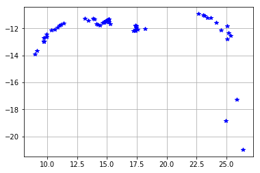

```python
import matplotlib
%matplotlib inline
from matplotlib import pyplot as plt

import numpy as np
x = np.log10(df_sed['freq'])
y = np.log10(df_sed['flux'])
#y = df_sed['flux']

plt.plot(x, y, 'b*')
plt.grid(True)
```